# YouTube View Prediction with Machine Learning

*Jingzong Wang*

2020-03

### Libraries and Setup

```python
! sudo apt install openjdk-8-jdk
! sudo update-alternatives --config java
```

```python
import numpy as np
import pandas as pd
import json
import matplotlib
import matplotlib.pyplot as plt
from matplotlib import cm
from datetime import datetime
import glob
import seaborn as sns
import re
import os
```

```python
import boto3
from botocore import UNSIGNED

from botocore.config import Config

s3 = boto3.resource('s3', config=Config(signature_version=UNSIGNED))
s3.Bucket('penn-cis545-files').download_file('youtube_data.zip', 'youtube_data.zip')

!unzip /content/youtube_data.zip
```

# Section 1 : Machine Learning with Sklearn

## 1.1 Data loading and Preprocessing

The dataset is a daily record of the top trending YouTube videos.

To determine the year’s top-trending videos, YouTube uses a combination of factors including measuring users interactions (number of views, shares, comments and likes). Top performers on the YouTube trending list are music videos (such as the famously viral “[Gangnam Style](https://www.youtube.com/watch?v=9bZkp7q19f0)”), celebrity and/or reality TV performances, and the random dude-with-a-camera viral videos that YouTube is well-known for.

This dataset includes several months (and counting) of data on daily trending YouTube videos. Data is included for numerous countries, with up to 200 listed trending videos per day.

Each region’s data is in a separate file. Data includes:

- Video Title
- Channel title
- Publish time
- Tags
- Views
- Likes
- Dislikes
- Description
- Comment count

The data also includes a category_id field, which varies between regions.

#### 1.1.1: Combining Multiple CSV's

There are multiple csv files in the dataset, each corresponding to a specific country. So, the first step is to read them and combine these csv files into a single dataframe.

```python
# Import all the csv files
files = [i for i in glob.glob('/content/youtube_data/*.csv'.format('csv'))]
sorted(files)
```

```
['/content/youtube_data/CAvideos.csv',
 '/content/youtube_data/FRvideos.csv',
 '/content/youtube_data/INvideos.csv',
 '/content/youtube_data/USvideos.csv']
```

```python
# Combine all into a single dataframe "combined_data" and add a 'country' column.
all_dataframes = list()
country=['CA','FR','IN','US']
i=0
for csv in files:
  all_dataframes = all_dataframes+[pd.read_csv(csv,header=[0]).set_index('video_id')]
  all_dataframes[i]['country']=country[i]
  i=i+1
combined_data = pd.concat(all_dataframes)
```

```python
combined_data
```

| video_id | trending_date | title | channel_title | category_id | publish_time | tags | views | likes | dislikes | comment_count | thumbnail_link | comments_disabled | ratings_disabled | video_error_or_removed | description | country |
| --- | --- | --- | --- | --- | --- | --- | --- | --- | --- | --- | --- | --- | --- | --- | --- | --- |
| 2kyS6SvSYSE | 17.14.11 | WE WANT TO TALK ABOUT OUR MARRIAGE | CaseyNeistat | 22 | 2017-11-13T17:13:01.000Z | SHANtell martin | 748374 | 57527 | 2966 | 15954 | https://i.ytimg.com/vi/2kyS6SvSYSE/default.jpg | False | False | False | SHANTELL'S CHANNEL - https://www.youtube.com/s... | CA |
| 1ZAPwfrtAFY | 17.14.11 | The Trump Presidency: Last Week Tonight with J... | LastWeekTonight | 24 | 2017-11-13T07:30:00.000Z | last week tonight trump presidency\|"last week ... | 2418783 | 97185 | 6146 | 12703 | https://i.ytimg.com/vi/1ZAPwfrtAFY/default.jpg | False | False | False | One year after the presidential election, John... | CA |
| 5qpjK5DgCt4 | 17.14.11 | Racist Superman \| Rudy Mancuso, King Bach & Le... | Rudy Mancuso | 23 | 2017-11-12T19:05:24.000Z | racist superman\|"rudy"\|"mancuso"\|"king"\|"bach"... | 3191434 | 146033 | 5339 | 8181 | https://i.ytimg.com/vi/5qpjK5DgCt4/default.jpg | False | False | False | WATCH MY PREVIOUS VIDEO ▶ \n\nSUBSCRIBE ► http... | CA |
| puqaWrEC7tY | 17.14.11 | Nickelback Lyrics: Real or Fake? | Good Mythical Morning | 24 | 2017-11-13T11:00:04.000Z | rhett and link\|"gmm"\|"good mythical morning"\|"... | 343168 | 10172 | 666 | 2146 | https://i.ytimg.com/vi/puqaWrEC7tY/default.jpg | False | False | False | Today we find out if Link is a Nickelback amat... | CA |
| d380meD0W0M | 17.14.11 | I Dare You: GOING BALD!? | nigahiga | 24 | 2017-11-12T18:01:41.000Z | ryan\|"higa"\|"higatv"\|"nigahiga"\|"i dare you"\|"... | 2095731 | 132235 | 1989 | 17518 | https://i.ytimg.com/vi/d380meD0W0M/default.jpg | False | False | False | I know it's been a while since we did this sho... | CA |
| ... | ... | ... | ... | ... | ... | ... | ... | ... | ... | ... | ... | ... | ... | ... | ... | ... |
| iNHecA3PJCo | 18.14.06 | फेकू आशिक़ - राजस्थान की सबसे शानदार कॉमेडी \| ... | RDC Rajasthani | 23 | 2018-06-13T08:01:11.000Z | twinkle vaishnav comedy\|"twinkle vaishnav"\|"tw... | 214378 | 3291 | 404 | 196 | https://i.ytimg.com/vi/iNHecA3PJCo/default.jpg | False | False | False | PRG Music & RDC Rajasthani presents फेकू आशिक़... | US |
| dpPmPbhcslM | 18.14.06 | Seetha \| Flowers \| Ep# 364 | Flowers TV | 24 | 2018-06-13T11:30:04.000Z | flowers serials\|"actress"\|"malayalam serials"\|... | 406828 | 1726 | 478 | 1428 | https://i.ytimg.com/vi/dpPmPbhcslM/default.jpg | False | False | False | Flowers - A R Rahman Show,Book your Tickets He... | US |
| mV6aztP58f8 | 18.14.06 | Bhramanam I Episode 87 - 12 June 2018 I Mazhav... | Mazhavil Manorama | 24 | 2018-06-13T05:00:02.000Z | mazhavil manorama\|"bhramanam full episode"\|"gt... | 386319 | 1216 | 453 | 697 | https://i.ytimg.com/vi/mV6aztP58f8/default.jpg | False | False | False | Subscribe to Mazhavil Manorama now for your da... | US |
| qxqDNP1bDEw | 18.14.06 | Nua Bohu \| Full Ep 285 \| 13th June 2018 \| Odia... | Tarang TV | 24 | 2018-06-13T15:07:49.000Z | tarang\|"tarang tv"\|"tarang tv online"\|"tarang ... | 130263 | 698 | 115 | 65 | https://i.ytimg.com/vi/qxqDNP1bDEw/default.jpg | False | False | False | Nuabohu : Story of a rustic village girl who w... | US |
| wERgpPK44w0 | 18.14.06 | Ee Nagaraniki Emaindi Trailer \| Tharun Bhascke... | Suresh Productions | 24 | 2018-06-10T04:29:54.000Z | Ee Nagaraniki Emaindi\|"Ee Nagaraniki Emaindi T... | 1278249 | 22466 | 1609 | 1205 | https://i.ytimg.com/vi/wERgpPK44w0/default.jpg | False | False | False | Check out Ee Nagaraniki Emaindi Trailer #EeNag... | US |

159906 rows × 16 columns

#### 1.1.2: Map category Id's to categories

```python
# Read the category_id.json file and map the category_id's in the dataframe to the category name.
combined_data['category_id'] = combined_data['category_id'].astype(str)

def find_title(item):
  return item['title']
category_df = pd.DataFrame(pd.read_json('/content/youtube_data/US_category_id.json').iloc[:,2].tolist())
category_df['title'] = category_df['snippet'].apply(find_title)
def map_cat(id_str):
  return category_df.loc[category_df.id==id_str,'title'].values[0]
combined_data.insert(4, 'category',combined_data['category_id'].apply(map_cat))
```

```python
combined_data
```

| video_id | trending_date | title | channel_title | category_id | category | publish_time | tags | views | likes | dislikes | comment_count | thumbnail_link | comments_disabled | ratings_disabled | video_error_or_removed | description | country |
| --- | --- | --- | --- | --- | --- | --- | --- | --- | --- | --- | --- | --- | --- | --- | --- | --- | --- |
| 2kyS6SvSYSE | 17.14.11 | WE WANT TO TALK ABOUT OUR MARRIAGE | CaseyNeistat | 22 | People & Blogs | 2017-11-13T17:13:01.000Z | SHANtell martin | 748374 | 57527 | 2966 | 15954 | https://i.ytimg.com/vi/2kyS6SvSYSE/default.jpg | False | False | False | SHANTELL'S CHANNEL - https://www.youtube.com/s... | CA |
| 1ZAPwfrtAFY | 17.14.11 | The Trump Presidency: Last Week Tonight with J... | LastWeekTonight | 24 | Entertainment | 2017-11-13T07:30:00.000Z | last week tonight trump presidency\|"last week ... | 2418783 | 97185 | 6146 | 12703 | https://i.ytimg.com/vi/1ZAPwfrtAFY/default.jpg | False | False | False | One year after the presidential election, John... | CA |
| 5qpjK5DgCt4 | 17.14.11 | Racist Superman \| Rudy Mancuso, King Bach & Le... | Rudy Mancuso | 23 | Comedy | 2017-11-12T19:05:24.000Z | racist superman\|"rudy"\|"mancuso"\|"king"\|"bach"... | 3191434 | 146033 | 5339 | 8181 | https://i.ytimg.com/vi/5qpjK5DgCt4/default.jpg | False | False | False | WATCH MY PREVIOUS VIDEO ▶ \n\nSUBSCRIBE ► http... | CA |
| puqaWrEC7tY | 17.14.11 | Nickelback Lyrics: Real or Fake? | Good Mythical Morning | 24 | Entertainment | 2017-11-13T11:00:04.000Z | rhett and link\|"gmm"\|"good mythical morning"\|"... | 343168 | 10172 | 666 | 2146 | https://i.ytimg.com/vi/puqaWrEC7tY/default.jpg | False | False | False | Today we find out if Link is a Nickelback amat... | CA |
| d380meD0W0M | 17.14.11 | I Dare You: GOING BALD!? | nigahiga | 24 | Entertainment | 2017-11-12T18:01:41.000Z | ryan\|"higa"\|"higatv"\|"nigahiga"\|"i dare you"\|"... | 2095731 | 132235 | 1989 | 17518 | https://i.ytimg.com/vi/d380meD0W0M/default.jpg | False | False | False | I know it's been a while since we did this sho... | CA |
| ... | ... | ... | ... | ... | ... | ... | ... | ... | ... | ... | ... | ... | ... | ... | ... | ... | ... |
| iNHecA3PJCo | 18.14.06 | फेकू आशिक़ - राजस्थान की सबसे शानदार कॉमेडी \| ... | RDC Rajasthani | 23 | Comedy | 2018-06-13T08:01:11.000Z | twinkle vaishnav comedy\|"twinkle vaishnav"\|"tw... | 214378 | 3291 | 404 | 196 | https://i.ytimg.com/vi/iNHecA3PJCo/default.jpg | False | False | False | PRG Music & RDC Rajasthani presents फेकू आशिक़... | US |
| dpPmPbhcslM | 18.14.06 | Seetha \| Flowers \| Ep# 364 | Flowers TV | 24 | Entertainment | 2018-06-13T11:30:04.000Z | flowers serials\|"actress"\|"malayalam serials"\|... | 406828 | 1726 | 478 | 1428 | https://i.ytimg.com/vi/dpPmPbhcslM/default.jpg | False | False | False | Flowers - A R Rahman Show,Book your Tickets He... | US |
| mV6aztP58f8 | 18.14.06 | Bhramanam I Episode 87 - 12 June 2018 I Mazhav... | Mazhavil Manorama | 24 | Entertainment | 2018-06-13T05:00:02.000Z | mazhavil manorama\|"bhramanam full episode"\|"gt... | 386319 | 1216 | 453 | 697 | https://i.ytimg.com/vi/mV6aztP58f8/default.jpg | False | False | False | Subscribe to Mazhavil Manorama now for your da... | US |
| qxqDNP1bDEw | 18.14.06 | Nua Bohu \| Full Ep 285 \| 13th June 2018 \| Odia... | Tarang TV | 24 | Entertainment | 2018-06-13T15:07:49.000Z | tarang\|"tarang tv"\|"tarang tv online"\|"tarang ... | 130263 | 698 | 115 | 65 | https://i.ytimg.com/vi/qxqDNP1bDEw/default.jpg | False | False | False | Nuabohu : Story of a rustic village girl who w... | US |
| wERgpPK44w0 | 18.14.06 | Ee Nagaraniki Emaindi Trailer \| Tharun Bhascke... | Suresh Productions | 24 | Entertainment | 2018-06-10T04:29:54.000Z | Ee Nagaraniki Emaindi\|"Ee Nagaraniki Emaindi T... | 1278249 | 22466 | 1609 | 1205 | https://i.ytimg.com/vi/wERgpPK44w0/default.jpg | False | False | False | Check out Ee Nagaraniki Emaindi Trailer #EeNag... | US |

159906 rows × 17 columns

#### 1.1.3: Fix datetime format and remove rows with NA's

```python
def trending_datetime(time):
  return pd.to_datetime('20'+time,format='%Y.%d.%m', errors='ignore')
combined_data['trending_date'] = combined_data['trending_date'].apply(trending_datetime)
combined_data['publish_time'] = pd.to_datetime(combined_data['publish_time'])

# remove NA's
combined_data = combined_data.dropna()
```

## 1.2 EDA and Feature Engineering

#### 1.2.1: Mean, standard deviation, min and max.

```python
# Print some simple statistics like mean, standard deviation, min annd max for each of the numerical features in the dataset.
maxs = combined_data[['views','likes','dislikes','comment_count']].apply(np.max,axis=0)
mins = combined_data[['views','likes','dislikes','comment_count']].apply(np.min,axis=0)
stds = combined_data[['views','likes','dislikes','comment_count']].apply(np.std,axis=0)
means = combined_data[['views','likes','dislikes','comment_count']].apply(np.mean,axis=0)
```

```python
maxs
```

```
views            225211923
likes              5613827
dislikes           1643059
comment_count      1228655
dtype: int64
```

```python
mins
```

```
views            223
likes              0
dislikes           0
comment_count      0
dtype: int64
```

```python
stds
```

```
views            4.605278e+06
likes            1.521485e+05
dislikes         1.825848e+04
comment_count    2.327815e+04
dtype: float64
```

```python
means
```

```
views            1.281578e+06
likes            4.096105e+04
dislikes         2.056138e+03
comment_count    4.606594e+03
dtype: float64
```

#### 1.2.2: Rescale features

```python
# Rescale the likes, views, dislkes and comment_count to log scale (base e) to avoid numerical instability issues
def plusone(num):
  return num+1
combined_data['likes_log'] = combined_data['likes'].apply(plusone).apply(np.log)
combined_data['views_log'] = combined_data['views'].apply(np.log)
combined_data['dislikes_log'] = combined_data['dislikes'].apply(plusone).apply(np.log)
combined_data['comment_log'] = combined_data['comment_count'].apply(plusone).apply(np.log)
```

#### 1.2.3: Plot the distribution

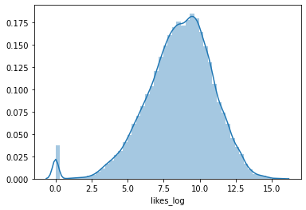

```python
sns.distplot(combined_data['likes_log'])
```

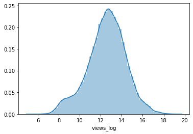

```python
sns.distplot(combined_data['views_log'])
```

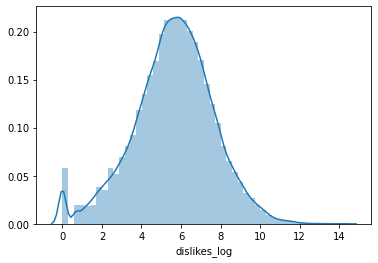

```python
sns.distplot(combined_data['dislikes_log'])
```

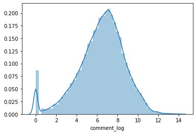

```python
sns.distplot(combined_data['comment_log'])
```

#### 1.2.4: Comparing views, likes, dislikes against categories

As a next step, we try to gain insights into the data using categories, views, likes and dislikes.

1. Number of videos for each category

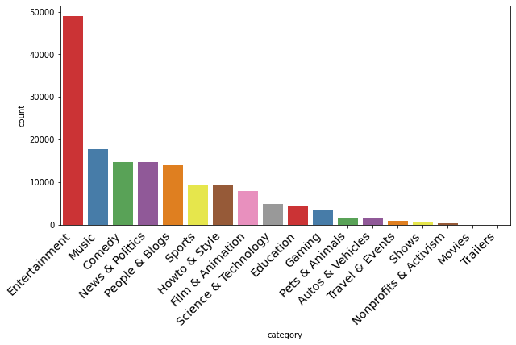

```python
# Number of videos for each category
plt.figure(figsize=(10,5))
chart = sns.countplot(
    data=combined_data,
    x='category',
    palette='Set1',
    order=combined_data['category'].value_counts().index
)

plt.xticks(
    rotation=45,
    horizontalalignment='right',
    fontweight='light',
    fontsize='x-large'
)
```

1. The distribution of category against views

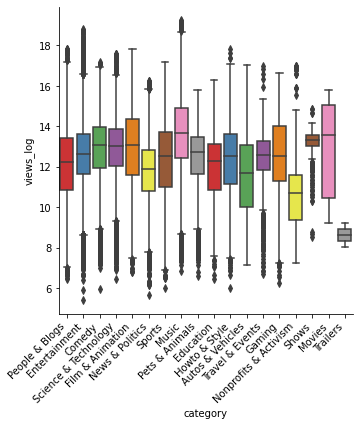

```python
# The distribution of category against views
chart = sns.catplot(
    data=combined_data,
    x='category',
    y='views_log',
    kind='box',
    palette='Set1'
)

plt.xticks(
    rotation=45,
    horizontalalignment='right',
    fontweight='light'
)
```

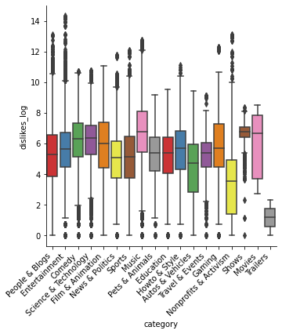

```python
# The distribution of dislikes against views
chart = sns.catplot(
    data=combined_data,
    x='category',
    y='dislikes_log',
    kind='box',
    palette='Set1'
)

plt.xticks(
    rotation=45,
    horizontalalignment='right',
    fontweight='light'
)
```

#### 1.2.5: Feature Engineering

##### a. Processing tags

```python
# Count the number of tags.
combined_data["num_tags"]=combined_data['tags'].apply(lambda x:x.count("|")+1)
```

##### b. Processing description and title

```python
# Compute the length of description
combined_data["desc_len"]=combined_data['description'].apply(len)
```

```python
# Compute the length of title
combined_data["len_title"]=combined_data['title'].apply(len)
```

##### c. Processing publish_time.

```python
# Split 'publish_time' feature into three parts time, date, and weekday
combined_data['publish_weekday']= combined_data['publish_time'].apply(lambda x:x.weekday()+1)
combined_data['publish_date'] = combined_data['publish_time'].apply(lambda x:x.date())
combined_data['publish_time'] = combined_data['publish_time'].apply(lambda x:x.time())
```

##### d. Number of videos per weekday

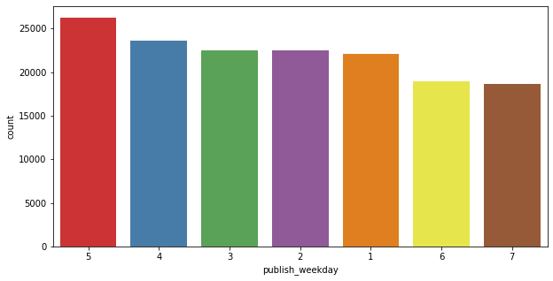

```python
# Compute the number of videos published per day of the week.
plt.figure(figsize=(10,5))
chart = sns.countplot(
    data=combined_data,
    x='publish_weekday',
    palette='Set1',
    order=combined_data['publish_weekday'].value_counts().index
)
```

#### 1.2.6: Drop all non numeric columns

```python
combined_data=combined_data.drop(['title', 'channel_title', 'category', 'tags', 'views', 'likes', 'dislikes', 'comment_count', 'thumbnail_link', 'thumbnail_link', 'description','publish_date', 'publish_time','trending_date'], axis=1)
```

#### 1.2.7: Convert categorical features in the dataset into one hot vectors.

```python
combined_data.publish_weekday = combined_data.publish_weekday.astype('category')
combined_data.country = combined_data.country.astype('category')

combined_data = pd.concat([combined_data, pd.get_dummies(combined_data['publish_weekday'])], axis=1)
combined_data = pd.concat([combined_data, pd.get_dummies(combined_data['country'])], axis=1)
combined_data = pd.concat([combined_data, pd.get_dummies(combined_data['category_id'])], axis=1)
combined_data = combined_data.drop(['category_id','country','publish_weekday'],axis=1)
```

```python
# Write out the modified data to a file
combined_data_sec_2 = combined_data.copy()
combined_data_sec_2.rename(columns = {'views_log':'label'}, inplace = True)
combined_data_sec_2.to_csv('combined_data.csv')
```

#### 1.2.8: Split into x and y

```python
# Split the data into features and label
combined_data=pd.read_csv('combined_data.csv').set_index('video_id')
```

```python
label = combined_data['label']
features = combined_data.drop(['label'],axis=1)
```

## 1.3 : Machine Learning using sklearn

### 1.3.1 : Split data into train and test

```python
from sklearn.model_selection import train_test_split

x_train, x_test, y_train, y_test = train_test_split(features, label, test_size=0.2)
```

### 1.3.2: Train Machine Learning Models.

#### 1.3.2.1 Linear Regression

```
Score: 0.8660262246648466
MAE: 0.5068012207962754
MSE: 0.44355818659686275
RMSE: 0.6660016415872132
```

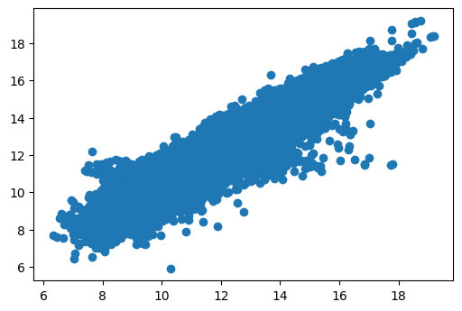

```python
from sklearn.linear_model import LinearRegression
from sklearn.metrics import mean_squared_error
from sklearn.metrics import accuracy_score, mean_absolute_error, mean_squared_error

clf = LinearRegression()
clf.fit(x_train, y_train)

y_pred = clf.predict(x_test)

print("Score:", clf.score(x_test, y_test))
plt.figure(dpi=100)
plt.scatter(y_test, y_pred)

# Different error measures
print("MAE:", mean_absolute_error(y_test, y_pred))
print('MSE:', mean_squared_error(y_test, y_pred))
print('RMSE:', np.sqrt(mean_squared_error(y_test, y_pred)))
```

#### 1.3.2.2 Dimensionality reduction with PCA

Use Principal component analysis to reduce number of dimensions of the dataset

```python
import numpy as np
from sklearn.decomposition import PCA
from sklearn.preprocessing import StandardScaler

# Fit a pca model on your train set
X = StandardScaler().fit_transform(features)
pca = PCA(n_components=38)
X2 = pca.fit_transform(X)
np.set_printoptions(suppress=True)
pca.explained_variance_ratio_
pc_vs_variance = np.cumsum(pca.explained_variance_ratio_)

# Plot the explained_variance_ratio against the number of components
pc_vs_variance
plt.plot(pc_vs_variance)
```

[output not shown]

```python
pca = PCA(n_components=31)
pca.fit(x_train)
x_train_2 = pca.transform(x_train)
```

### 1.3.2.3 Random Forest.

```python
from sklearn.ensemble import RandomForestRegressor
from sklearn.model_selection import GridSearchCV
# Grid search
param_grid = {
    'n_estimators'     : [20,30,40],
    'max_depth'        : [8,12,16]
}
CV_clf = GridSearchCV(estimator=RandomForestRegressor(), param_grid=param_grid,cv=3)
CV_clf.fit(x_train_2, y_train)
CV_clf.best_params_
```

```
{'max_depth': 16, 'n_estimators': 40}
```

```python
# Fit the random forest on the traing data
rfr = RandomForestRegressor(max_depth=16,n_estimators=40)
rfr.fit(x_train_2,y_train)
pca = PCA(n_components=31)
pca.fit(x_test)
x_test_2 = pca.transform(x_test)

# Make predictions
y_pred=rfr.predict(x_test_2)
```

```python
np.sqrt(mean_squared_error(y_test, y_pred))
```

[output not shown]

# Section 2 : Distributed Machine Learning with Spark

### Initializing Spark Connection

```python
!apt install libkrb5-dev
!wget https://www-us.apache.org/dist/spark/spark-2.4.5/spark-2.4.5-bin-hadoop2.7.tgz
!tar xf spark-2.4.5-bin-hadoop2.7.tgz
!pip install findspark
!pip install sparkmagic
!pip install pyspark
!pip install pyspark --user
!pip install seaborn --user
!pip install plotly --user
!pip install imageio --user
!pip install folium --user
```

```python
!apt update
!apt install gcc python-dev libkrb5-dev
```

```python
from pyspark.sql import SparkSession
from pyspark.sql.types import *
import pyspark.sql.functions as F

import os

spark = SparkSession.builder.appName('ml-hw4').getOrCreate()
```

```python
%load_ext sparkmagic.magics
```

```
The sparkmagic.magics extension is already loaded. To reload it, use:
  %reload_ext sparkmagic.magics
```

```python
#graph section
import networkx as nx
# SQLite RDBMS
import sqlite3
# Parallel processing
# import swifter
import pandas as pd
# NoSQL DB
from pymongo import MongoClient
from pymongo.errors import DuplicateKeyError, OperationFailure

import os
os.environ['SPARK_HOME'] = '/content/spark-2.4.5-bin-hadoop2.7'
os.environ["JAVA_HOME"] = "/usr/lib/jvm/java-8-openjdk-amd64"
import pyspark
from pyspark.sql import SQLContext
```

```python
try:
    if(spark == None):
        spark = SparkSession.builder.appName('Initial').getOrCreate()
        sqlContext=SQLContext(spark)
except NameError:
    spark = SparkSession.builder.appName('Initial').getOrCreate()
    sqlContext=SQLContext(spark)
```

### 2.1 Data for Spark ML

```python
train_sdf = spark.read.format('csv').options(header='true', inferSchema='true').load('combined_data.csv')
```

```python
train_sdf.show()
```

```
+-----------+-----------------+----------------+----------------------+------------------+------------------+------------------+------------------+--------+--------+---------+---+---+---+---+---+---+---+---+---+---+---+---+---+---+---+---+---+---+---+---+---+---+---+---+---+---+---+---+---+
|   video_id|comments_disabled|ratings_disabled|video_error_or_removed|         likes_log|             label|      dislikes_log|       comment_log|num_tags|desc_len|len_title|111|212|  3|  4|  5|  6|  7| CA| FR| IN| US|122| 10| 15| 17| 19|227| 20| 22| 23| 24| 25| 26| 27| 28| 29| 30| 43| 44|
+-----------+-----------------+----------------+----------------------+------------------+------------------+------------------+------------------+--------+--------+---------+---+---+---+---+---+---+---+---+---+---+---+---+---+---+---+---+---+---+---+---+---+---+---+---+---+---+---+---+---+
|2kyS6SvSYSE|            false|           false|                 false| 10.96002706478233|13.525658131998265| 7.995306620290822| 9.677527538712344|       1|    1410|       34|  1|  0|  0|  0|  0|  0|  0|  1|  0|  0|  0|  0|  0|  0|  0|  0|  0|  0|  1|  0|  0|  0|  0|  0|  0|  0|  0|  0|  0|
|1ZAPwfrtAFY|            false|           false|                 false|11.484381947152983|14.698775079078011|  8.72371943690701| 9.449672183486918|       4|     630|       62|  1|  0|  0|  0|  0|  0|  0|  1|  0|  0|  0|  0|  0|  0|  0|  0|  0|  0|  0|  0|  1|  0|  0|  0|  0|  0|  0|  0|  0|
|5qpjK5DgCt4|            false|           false|                 false| 11.89159475029123| 14.97598090353335| 8.582980931954241| 9.009691898489343|      23|    1177|       53|  0|  0|  0|  0|  0|  0|  1|  1|  0|  0|  0|  0|  0|  0|  0|  0|  0|  0|  0|  1|  0|  0|  0|  0|  0|  0|  0|  0|  0|
|puqaWrEC7tY|            false|           false|                 false| 9.227492430793749|12.745975402155576| 6.502790045915623| 7.671826797878781|      27|    1403|       32|  1|  0|  0|  0|  0|  0|  0|  1|  0|  0|  0|  0|  0|  0|  0|  0|  0|  0|  0|  0|  1|  0|  0|  0|  0|  0|  0|  0|  0|
|d380meD0W0M|            false|           false|                 false|11.792343484003547| 14.55541297649217| 7.595889917718538| 9.771041285235823|      14|     636|       24|  0|  0|  0|  0|  0|  0|  1|  1|  0|  0|  0|  0|  0|  0|  0|  0|  0|  0|  0|  0|  1|  0|  0|  0|  0|  0|  0|  0|  0|
|gHZ1Qz0KiKM|            false|           false|                 false| 9.186457431512851| 11.68839023430097| 6.238324625039508| 7.268920128193722|       7|    1511|       21|  1|  0|  0|  0|  0|  0|  0|  1|  0|  0|  0|  0|  0|  0|  0|  0|  0|  0|  0|  0|  0|  0|  0|  0|  1|  0|  0|  0|  0|
|39idVpFF7NQ|            false|           false|                 false| 9.679968930891835| 14.55907372318811| 7.802209316247118|  7.58629630715272|      42|     503|       41|  0|  0|  0|  0|  0|  0|  1|  1|  0|  0|  0|  0|  0|  0|  0|  0|  0|  0|  0|  0|  1|  0|  0|  0|  0|  0|  0|  0|  0|
|nc99ccSXST0|            false|           false|                 false| 10.07171018495058|13.614289933541128| 6.658011045870748| 8.141189793457691|      13|     734|       35|  0|  0|  0|  0|  0|  0|  1|  1|  0|  0|  0|  0|  0|  0|  0|  0|  0|  0|  0|  0|  0|  0|  0|  0|  1|  0|  0|  0|  0|
|jr9QtXwC9vc|            false|           false|                 false| 8.173011311724972|13.624421478523645| 4.787491742782046| 5.831882477283517|      28|    1310|       65|  1|  0|  0|  0|  0|  0|  0|  1|  0|  0|  0|  1|  0|  0|  0|  0|  0|  0|  0|  0|  0|  0|  0|  0|  0|  0|  0|  0|  0|
|TUmyygCMMGA|            false|           false|                 false| 9.445807672979225| 12.45459540294377| 7.218176838403408|7.7702232041587855|      20|    2257|       53|  1|  0|  0|  0|  0|  0|  0|  1|  0|  0|  0|  0|  0|  0|  0|  0|  0|  0|  0|  0|  0|  1|  0|  0|  0|  0|  0|  0|  0|
|9wRQljFNDW8|            false|           false|                 false| 6.486160788944089|11.306847956781812| 3.258096538021482| 5.181783550292085|      49|    1290|       86|  1|  0|  0|  0|  0|  0|  0|  1|  0|  0|  0|  0|  0|  0|  1|  0|  0|  0|  0|  0|  0|  0|  0|  0|  0|  0|  0|  0|  0|
|VifQlJit6A0|            false|           false|                 false|7.3632795869630385|11.557688483443744| 5.717027701406222| 7.154615356913663|      40|     819|       78|  1|  0|  0|  0|  0|  0|  0|  1|  0|  0|  0|  0|  0|  0|  0|  0|  0|  0|  0|  0|  1|  0|  0|  0|  0|  0|  0|  0|  0|
|5E4ZBSInqUU|            false|           false|                 false| 11.64561024932308| 13.44093637413771| 7.195937226475569|  9.03264808356589|      23|    1042|       42|  1|  0|  0|  0|  0|  0|  0|  1|  0|  0|  0|  0|  1|  0|  0|  0|  0|  0|  0|  0|  0|  0|  0|  0|  0|  0|  0|  0|  0|
```

[output cut: 9 more lines]

```python
#Print the dataframe schema and verify
train_sdf.printSchema()
```

```
root
 |-- video_id: string (nullable = true)
 |-- comments_disabled: boolean (nullable = true)
 |-- ratings_disabled: boolean (nullable = true)
 |-- video_error_or_removed: boolean (nullable = true)
 |-- likes_log: double (nullable = true)
 |-- label: double (nullable = true)
 |-- dislikes_log: double (nullable = true)
 |-- comment_log: double (nullable = true)
 |-- num_tags: integer (nullable = true)
 |-- desc_len: integer (nullable = true)
 |-- len_title: integer (nullable = true)
 |-- 111: integer (nullable = true)
 |-- 212: integer (nullable = true)
 |-- 3: integer (nullable = true)
 |-- 4: integer (nullable = true)
 |-- 5: integer (nullable = true)
 |-- 6: integer (nullable = true)
 |-- 7: integer (nullable = true)
 |-- CA: integer (nullable = true)
 |-- FR: integer (nullable = true)
 |-- IN: integer (nullable = true)
 |-- US: integer (nullable = true)
 |-- 122: integer (nullable = true)
 |-- 10: integer (nullable = true)
 |-- 15: integer (nullable = true)
 |-- 17: integer (nullable = true)
 |-- 19: integer (nullable = true)
 |-- 227: integer (nullable = true)
 |-- 20: integer (nullable = true)
 |-- 22: integer (nullable = true)
 |-- 23: integer (nullable = true)
 |-- 24: integer (nullable = true)
 |-- 25: integer (nullable = true)
 |-- 26: integer (nullable = true)
 |-- 27: integer (nullable = true)
 |-- 28: integer (nullable = true)
 |-- 29: integer (nullable = true)
 |-- 30: integer (nullable = true)
 |-- 43: integer (nullable = true)
 |-- 44: integer (nullable = true)
```

```python
from pyspark.ml.feature import StringIndexer, VectorAssembler
```

```python
# Drop unwanted columns
all_columns = train_sdf.columns
drop_columns = ['video_id','label']
columns_to_use = [i for i in all_columns if i not in drop_columns]
```

```python
# Create a VectorAssembler object
assembler = VectorAssembler(inputCols=columns_to_use, outputCol='features')
```

In this step, we will create a pipeline with a single stage - the assembler.

```python
from pyspark.ml import Pipeline
# Create a pipeline
pipeline = Pipeline(stages=[assembler])
modified_data_sdf = pipeline.fit(train_sdf).transform(train_sdf).drop(*columns_to_use)
```

```python
modified_data_sdf.show()
```

```
+-----------+------------------+--------------------+
|   video_id|             label|            features|
+-----------+------------------+--------------------+
|2kyS6SvSYSE|13.525658131998265|(38,[3,4,5,6,7,8,...|
|1ZAPwfrtAFY|14.698775079078011|(38,[3,4,5,6,7,8,...|
|5qpjK5DgCt4| 14.97598090353335|(38,[3,4,5,6,7,8,...|
|puqaWrEC7tY|12.745975402155576|(38,[3,4,5,6,7,8,...|
|d380meD0W0M| 14.55541297649217|(38,[3,4,5,6,7,8,...|
|gHZ1Qz0KiKM| 11.68839023430097|(38,[3,4,5,6,7,8,...|
|39idVpFF7NQ| 14.55907372318811|(38,[3,4,5,6,7,8,...|
|nc99ccSXST0|13.614289933541128|(38,[3,4,5,6,7,8,...|
|jr9QtXwC9vc|13.624421478523645|(38,[3,4,5,6,7,8,...|
|TUmyygCMMGA| 12.45459540294377|(38,[3,4,5,6,7,8,...|
|9wRQljFNDW8|11.306847956781812|(38,[3,4,5,6,7,8,...|
|VifQlJit6A0|11.557688483443744|(38,[3,4,5,6,7,8,...|
|5E4ZBSInqUU| 13.44093637413771|(38,[3,4,5,6,7,8,...|
|GgVmn66oK_A|13.208118966221953|(38,[3,4,5,6,7,8,...|
|TaTleo4cOs8|12.243040823630162|(38,[3,4,5,6,7,8,...|
|kgaO45SyaO4|11.235220125663336|(38,[3,4,5,6,7,8,...|
|ZAQs-ctOqXQ|12.596894394400882|(38,[3,4,5,6,7,8,...|
|YVfyYrEmzgM| 11.26502804918979|(38,[3,4,5,6,7,8,...|
|eNSN6qet1kE| 11.48253841983021|(38,[3,4,5,6,7,8,...|
|B5HORANmzHw| 12.31882527209005|(38,[3,4,5,6,7,8,...|
+-----------+------------------+--------------------+
only showing top 20 rows
```

```python
# Split into an 80-20 ratio between the train and test sets.
train_sdf, test_sdf = modified_data_sdf.randomSplit([0.8, 0.2], seed = 2020)
```

### 2.2 Linear regression using Spark ML

Using Spark ML's linear regression to Train a linear regression model and try to predict the views.

```python
from pyspark.ml.regression import LinearRegression

# Train a linear regression model
lr = LinearRegression(featuresCol = 'features', labelCol='label')
lr_model = lr.fit(train_sdf)
```

```python
trainingSummary = lr_model.summary

print("RMSE: %f" % trainingSummary.rootMeanSquaredError)
print("r2: %f" % trainingSummary.r2)
```

```
RMSE: 0.666726
r2: 0.865483
```

```python
predictions = lr_model.transform(test_sdf)
```

```python
from pyspark.ml.evaluation import RegressionEvaluator

# Compute root mean squared error on the test set
test_result = lr_model.evaluate(test_sdf)
test_rmse_orig = test_result.rootMeanSquaredError
```

```python
test_rmse_orig
```

```
0.6707749535378126
```

```python
# Add regularization to avoid overfitting, try out L1, L2 and elastic net
lrl1 = LinearRegression(featuresCol = 'features', labelCol='label',regParam=0.1,elasticNetParam=1.0)
lrl1_model = lrl1.fit(train_sdf)
lrl2 = LinearRegression(featuresCol = 'features', labelCol='label',regParam=0.2,elasticNetParam=0.0)
lrl2_model = lrl2.fit(train_sdf)
lre = LinearRegression(featuresCol = 'features', labelCol='label',regParam=0.1,elasticNetParam=0.5)
lre_model = lre.fit(train_sdf)
```

```python
# Compute predictions using each of the models
l1_predictions = lrl1_model.transform(test_sdf)
l2_predictions = lrl2_model.transform(test_sdf)
elastic_net_predictions = lre_model.transform(test_sdf)

# Compute root mean squared error on test set for each of your models
test_result_l1 = lrl1_model.evaluate(test_sdf)
test_rmse_l1 = test_result_l1.rootMeanSquaredError

test_result_l2 = lrl2_model.evaluate(test_sdf)
test_rmse_l2 = test_result_l2.rootMeanSquaredError

test_result_e = lre_model.evaluate(test_sdf)
test_rmse_elastic = test_result_e.rootMeanSquaredError
```

```python
print(test_rmse_l1)
print(test_rmse_l2)
print(test_rmse_elastic)
```

[output not shown]

### 2.3 Random Forest Regression

```python
from pyspark.ml.regression import RandomForestRegressor
# Create a random forest regressor model, fit the training data and evaluate using RegressionEvaluator
rf_reg = RandomForestRegressor(labelCol="label", featuresCol="features")
rf_model = rf_reg.fit(train_sdf)
train_pred = rf_model.transform(train_sdf)
evaluator = RegressionEvaluator(labelCol="label", predictionCol="prediction", metricName="rmse")
train_rmse_rf =  evaluator.evaluate(train_pred)#TODO: calculate the training rmse
train_rmse_rf
```

```
0.7166346288805886
```

```python
# Predictions on the test set
predictions = rf_model.transform(test_sdf)
```

```python
from pyspark.ml.evaluation import RegressionEvaluator

# Calculate the rmse on the test set
rmse_rf = evaluator.evaluate(predictions)
rmse_rf
```

```
0.7176383770276658
```

### 2.4 Dimensionality Reduction using PCA

```python
from pyspark.ml.regression import LinearRegression
from pyspark.ml.feature import PCA as PCAml
pca = PCAml(k=31, inputCol='features', outputCol='pcaFeature')
pca_fit = pca.fit(train_sdf)
train_sdf_pca=pca_fit.transform(train_sdf)
pca_model = lr.fit(train_sdf_pca)
pcaSummary = pca_model.summary
training_rmse_pca = pcaSummary.rootMeanSquaredError
training_rmse_pca
```

```python
training_rmse_pca
```

```
0.6667264867184813
```

```python
# Your code goes here
from pyspark.ml.evaluation import RegressionEvaluator

test_sdf_pca=pca_fit.transform(test_sdf)
# Get predictions on the test set
predictions_pca = pca_model.transform(test_sdf_pca)
test_result_pca = pca_model.evaluate(test_sdf_pca)
# Get RMSE for test data
test_rmse_pca = test_result_pca.rootMeanSquaredError #TODO: Get RMSE for test data
test_rmse_pca
```

```
0.6707749535378126
```